# DESeq2 Demonstration

Shelby Blythe

11/8/2021

# Introduction

It is common to want to ask whether count-based genomic data collected under different experimental conditions yields “statistically significant differences” between regions of interest. It is useful to not only determine these differences within a dataset for their own sake, but also to use this information to categorize these regions and ask whether correlations exist between your new significant regions and other known genomic features, like promoters, enhancers, UTRs, or transcription factor binding sites.

In this course, we have provided you with all the skills necessary for performing differential enrichment analysis.

To do this analysis, first you need:

1. Count data (bam files or genomic ranges) for two or more replicates per condition that you would like to compare. Replicates are critical. This doesn’t work with single sample replicates.
2. A set of regions of interest (peaks, promoters, genes…) to count over. As we’ve discussed in class, whether you call peaks on your data *de novo*, or whether you use either an existing peak list, or an independent genomic feature is up to you and depends on your experimental question.

You then count how many reads in the data overlap with the regions of interest and generate a table where rows are regions of interest and columns are samples/replicates.

You annotate this table with sufficient metadata to identify what sample/replicate corresponds to each column, as well as any other useful information (condition, genotype, timepoint, whatever).

The count table and the metadata must be generated to an exact formatting (columns in counts correspond to rows in metadata. metadata columns are factorized. the reference level of each factor is your ‘control’ or reference value…)

This table, formatted properly, can now be analyzed for ‘differential enrichment’ using `DESeq2`, comparing replicates corresponding to one group versus replicates corresponding to another group.

How DESeq2 works is beyond the scope of this demonstration, but I highly highly recommend the [Harvard Chan Bioinformatics Core teaching module on DESeq2](https://hbctraining.github.io/DGE_workshop/lessons/04_DGE_DESeq2_analysis.html) and following pages. The DESeq2 vignette (google it) is also very helpful.

DESeq2 will report for each region in the set of regions of interest the average coverage, the log2 fold-change, as well as an adjusted p-value indicating the likelihood that the value observed in one group would have randomly been drawn from the other group by random chance.

Below, I demonstrate how to set up DESeq2 for a published paired end dataset corresponding to an ATAC-seq experiment. For this experiment, I have collected samples from either wild-type embryos, or embryos mis-expressing a pioneer factor of interest. We have a suitable peaks list to count over, and we also know where in the genome the pioneer factor normally likes to bind. Importantly, I also have a metadata table for this experiment that we can rapidly convert to a suitable metadata table for DESeq.

Below, I will show you what the input data looks like. I will show you how to perform counting of overlaps between the ATAC data and a set of peaks. I will show you how to format the metadata for DESeq (`coldata`). We will perform DESeq2 analysis.

With this information, I will show an example of PCA to examine the sources of variance amongst the ATAC samples, MA-plots, Volcano Plots, and a statistical test to ask if the regions that DESeq2 scores as ‘significant’ are over-represented for sites bound by the pioneer factor as determined by ChIP-seq.

Unlike most of this class, the goal with this demonstration is not for you to replicate these analyses yourself as we go. This is meant to be a concrete example for you to refer to down the line when you have your data in a suitable condition to begin doing your own analysis.

Again, you have all the tools to understand what follows, if it isn’t crystal clear as you go through this demonstration, I am sure that with significant study, you too will be doing these analyses yourself in no time.

## Demonstration

### Setup:

Clear the workspace, collect garbage, load the necessary packages, assign filepaths to the necessary input data to variables, load up the data and combine as necessary. *Note all filepaths are relevant only to my system* These data are available on my github repository https://www.github.com/sblythe/Patternless_ATAC

```r
rm(list = ls()); gc()
```

```
##          used (Mb) gc trigger (Mb) limit (Mb) max used (Mb)
## Ncells 471508 25.2    1013724 54.2         NA   666882 35.7
## Vcells 890360  6.8    8388608 64.0      65536  1826466 14.0
```

```r
suppressPackageStartupMessages(
  {
  library(DESeq2)
  library(GenomicRanges)
  library(tidyverse)
  library(ggthemes)
    }
)

# Filepath to ATAC peaks
peakfile = "~/Dropbox/Blythe Lab/Patternless Paper/Patternless_ATAC/All_Samples_shortreads_q1e-5_MACS2_peaks.narrowPeak.GR"

# Filepath to ChIP peaks
peakfile2 = "~/Dropbox/Blythe Lab/Patternless Paper/Patternless_ATAC/opa.ChIP.peaks_IDR_filtered.GR"

# Filepaths to ATAC datasets: grouped by sample type, Genomic Ranges corresponding to short "open" ATAC-seq reads in GRangesList format.

tubATACreads = "~/Dropbox/Blythe Lab/Patternless Paper/Patternless_ATAC/tub-opa_all_open_reads_list.R"
wt13ATACreads = "~/Dropbox/Blythe Lab/Patternless Paper/Patternless_ATAC/wt_NC13+12_all_open_reads_list.R"

# Filepath to the metadata table describing this experiment.
tubmetafile = "~/Dropbox/Blythe Lab/Patternless Paper/Patternless_ATAC/190813_ATAC_library_prep_metadata.txt"

# load the metadata
tubmeta = read.delim(tubmetafile, stringsAsFactors = FALSE, sep = "\t", header = TRUE) # "tubmeta"

# load the ATAC peaks
load(peakfile) # "peaks"

# load the ChIP peaks
load(peakfile2) # "opa.ChIP.peaks"

# join peak lists. To ensure that all of the ChIP peaks are represented in the ATAC peaks, we use GenomicRanges::reduce to combine the two peaks lists.

orig.atac.peaks = peaks # keep the originals in case we need to refer to them.
orig.opa.peaks = opa.ChIP.peaks
mcols(opa.ChIP.peaks) = NULL
genome(opa.ChIP.peaks) = 'dm6'
mcols(peaks) = NULL
peaks = GenomicRanges::reduce(c(peaks, opa.ChIP.peaks))

# remove uninteresting chromosomes from the peaks list
peaks = peaks[seqnames(peaks) %in% paste0('chr', c('2L','2R','3L','3R','4','X'))]

seqlevels(peaks) = seqlevelsInUse(peaks)
genome(peaks) = 'dm6'

# load the ATAC datasets
load(tubATACreads)
load(wt13ATACreads)

# combine the two ATAC datasets into one GRangesList object. Remove the two original datasets.

tubopen = GRangesList(c(wt.open, tub.open))
rm(list = c("tub.open", "wt.open"))
```

Let’s examine the form of the input datasets. First we have ATAC-seq reads in GRangesList format.

```r
summary(tubopen)
```

```
## [1] "GRangesList object of length 12 with 0 metadata columns"
```

We have 12 samples (6 replicates per condition).

Each GRangesList entry has a `name` that tells us what sample it corresponds to.

```r
names(tubopen)
```

```
##  [1] "19081101" "19081102" "19081103" "19081206" "19081207" "19081208"
##  [7] "19081104" "19081105" "19081201" "19081202" "19081204" "19081205"
```

For this experiment, each sample is identified by a serial number that corresponds to the date+N for the individual embryo that was processed to make the ATAC library. To know who is who, we have a metadata table.

```r
head(tubmeta)
```

```
##          sample.name               genotype   stage collection.temp  prep.date
## 19081101    19081101              w; HisGFP NC13+12            21.2 2019-08-11
## 19081102    19081102              w; HisGFP NC13+12            21.2 2019-08-11
## 19081103    19081103              w; HisGFP NC13+12            21.5 2019-08-11
## 19081104    19081104 w; tub>opa/+; HisGFP/+ NC13+12            21.2 2019-08-11
## 19081105    19081105 w; tub>opa/+; HisGFP/+ NC13+12            21.5 2019-08-11
## 19081201    19081201 w; tub>opa/+; HisGFP/+ NC13+12            21.5 2019-08-12
##          UDI PCR.cycles concentration_ng_ul starting.DNA  SDs bioanalyzer
## 19081101   1         13               19.10        0.035 1.31          ok
## 19081102   2         13               10.30        0.019 0.94        good
## 19081103   3         13               13.70        0.025 0.07        good
## 19081104   4         13                7.64        0.014 1.62        good
## 19081105   5         13               10.40        0.019 0.91        good
## 19081201   6         13               10.90        0.020 0.79        good
##          i7.barcode i5.barcode.Nextseq sex X_to_A mapped.reads.nodups.filtered
## 19081101   TTACCGAC           CGTATTCG   F   1.00                     26124638
## 19081102   TCGTCTGA           TCAAGGAC   F   1.00                     24652944
## 19081103   TTCCAGGT           AAGCACTG   M   0.55                     23687714
## 19081104   TACGGTCT           GCAATGGA   M   0.56                     26379436
## 19081105   AAGACCGT           CAATCGAC   M   0.57                     26216090
## 19081201   CAGGTTCA           GGCGTTAT   F   1.10                     25489242
```

I routinely collect all information about an ATAC sample into a table like this one. In this context, we could in principle perform DESeq over any of the categorical values in this table. We will be particularly focused on the `genotype` column, but we could in principle do it on the basis of the embryo `sex`, or the `prep.date` if we suspected that either of those variables was significantly contributing to the difference between samples.

Finally, we have a peaks list, which is a standard Genomic Ranges object.

```r
peaks
```

```
## GRanges object with 33992 ranges and 0 metadata columns:
##           seqnames            ranges strand
##              <Rle>         <IRanges>  <Rle>
##       [1]    chr2L         5505-6046      *
##       [2]    chr2L         6585-6881      *
##       [3]    chr2L         7521-7933      *
##       [4]    chr2L         8741-8994      *
##       [5]    chr2L       12481-12571      *
##       ...      ...               ...    ...
##   [33988]     chrX 23403183-23403251      *
##   [33989]     chrX 23460838-23460946      *
##   [33990]     chrX 23469707-23469808      *
##   [33991]     chrX 23470940-23470999      *
##   [33992]     chrX 23472561-23472676      *
##   -------
##   seqinfo: 6 sequences from dm6 genome
```

To do DESeq, we first need to count reads overlapping the peaks list. To simplify matters, we first put the ATAC samples in the same order as the metadata list.

```r
# put the data in the same order as the metadata list.
tubopen = tubopen[match(tubmeta[, 1], names(tubopen))]
```

The peaks list, as you see above, has no identifying features. We want to give each peak a useful name.

```r
# name each peak with something useful:
names(peaks) = paste0(seqnames(peaks),":",start(peaks),"-",end(peaks))

head(peaks)
```

```
## GRanges object with 6 ranges and 0 metadata columns:
##                     seqnames      ranges strand
##                        <Rle>   <IRanges>  <Rle>
##     chr2L:5505-6046    chr2L   5505-6046      *
##     chr2L:6585-6881    chr2L   6585-6881      *
##     chr2L:7521-7933    chr2L   7521-7933      *
##     chr2L:8741-8994    chr2L   8741-8994      *
##   chr2L:12481-12571    chr2L 12481-12571      *
##   chr2L:12795-12924    chr2L 12795-12924      *
##   -------
##   seqinfo: 6 sequences from dm6 genome
```

Now we are ready to count how many records in each ATAC dataset overlaps each peak. To do this we combine `lapply` and `countOverlaps`. The output of `lapply` is a list, but we want a table. We therefore use `do.call` to apply the function `cbind` to each element of the list to construct a table.

```r
# count reads in the ATAC data over the set of regions of interest
tubcounts = lapply(tubopen, function(x) countOverlaps(peaks, x))
tubcounts = do.call("cbind", tubcounts)

head(tubcounts)
```

```
##                   19081101 19081102 19081103 19081104 19081105 19081201
## chr2L:5505-6046         93      144      159      103      120       91
## chr2L:6585-6881         31       37       47       33       43       41
## chr2L:7521-7933         46       47       49       29       28       30
## chr2L:8741-8994         35       32       38       25       28       28
## chr2L:12481-12571        9       14        4        3        9       12
## chr2L:12795-12924       30       30       30       13       18       20
##                   19081202 19081204 19081205 19081206 19081207 19081208
## chr2L:5505-6046        104      159      141      165      133      113
## chr2L:6585-6881         40       69       42       58       36       33
## chr2L:7521-7933         33       49       43       46       38       34
## chr2L:8741-8994         26       39       22       42       21       21
## chr2L:12481-12571       11        8       10        9       12       11
## chr2L:12795-12924       14       21       15       29       20       16
```

These are the counts. Note, rows are peaks, columns are samples. Both are labeled.

**For DESeq2, it is obligatory that the counts not be normalized to anything. We do not CPM normalize these reads or modify them in any way. The values must be integers.**

Before we can do DESeq, we want to extract data from the metadata table and construct a suitable column data object for DESeq. We will call this `tcoldata`. For our analysis, we will be comparing between genotypes. Therefore the necessary column data to specify in our table is 1) the sample name, 2) the genotype. We also construct a name for each sample that combines the terse serial number with the genotype to make it more clear what sample is what. *We must have concordance between the `rownames` of the column data table and the `colnames` of the count table.*

```r
# generate the column data from the metadata file
shortgeno = rep(NA, nrow(tubmeta))
shortgeno[tubmeta$genotype %in% "w; HisGFP"] = "wt13"
shortgeno[tubmeta$genotype %in% "w; tub>opa/+; HisGFP/+"] = "tubopa"

rownames(tubmeta) = paste0(rownames(tubmeta), "_", shortgeno)
colnames(tubcounts) = paste0(colnames(tubcounts), "_", shortgeno)

tcoldata = data.frame(sample.name = tubmeta$sample.name, genotype = shortgeno, sex = tubmeta$sex)
rownames(tcoldata) = rownames(tubmeta)

# convert all columns to 'factor'
for (i in 1:ncol(tcoldata)) {
    tcoldata[, i] = as.factor(tcoldata[, i])
}

# create an ordering vector:
orderer = c(which(tcoldata[, 2] == "wt13"), which(tcoldata[, 2] == "tubopa"))

# reorder the counts table:
tubcounts = tubcounts[, orderer]

# reorder the coldata table:
tcoldata = tcoldata[orderer, ]

# make sure the intended reference factor levels are the first factor levels
tcoldata[, 2] = relevel(tcoldata[, 2], ref = "wt13")

# check that everything is in register:
all(rownames(tcoldata) %in% colnames(tubcounts))
```

```
## [1] TRUE
```

```r
all(rownames(tcoldata) == colnames(tubcounts))
```

```
## [1] TRUE
```

```r
tcoldata
```

```
##                 sample.name genotype sex
## 19081101_wt13      19081101     wt13   F
## 19081102_wt13      19081102     wt13   F
## 19081103_wt13      19081103     wt13   M
## 19081206_wt13      19081206     wt13   M
## 19081207_wt13      19081207     wt13   M
## 19081208_wt13      19081208     wt13   F
## 19081104_tubopa    19081104   tubopa   M
## 19081105_tubopa    19081105   tubopa   M
## 19081201_tubopa    19081201   tubopa   F
## 19081202_tubopa    19081202   tubopa   F
## 19081204_tubopa    19081204   tubopa   F
## 19081205_tubopa    19081205   tubopa   F
```

### DESeq2:

Before we do the analysis, we want to get rid of regions in the table that have low counts. First we should try plotting the distribution of the “row Sums”…

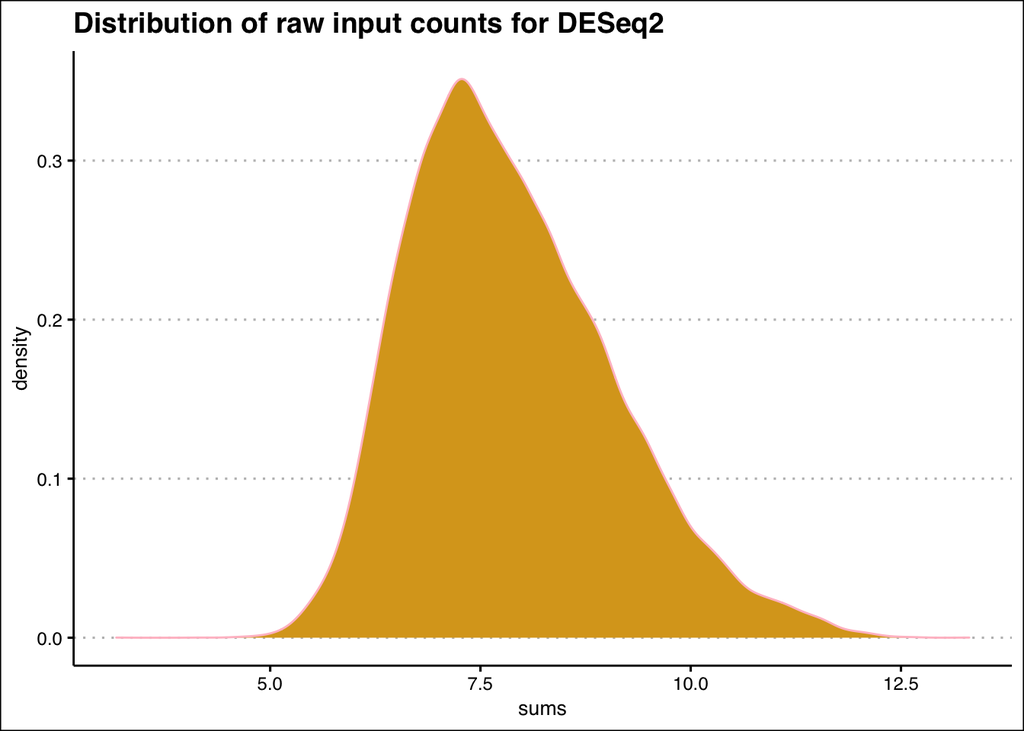

```r
data.frame(sums = log2(rowSums(tubcounts)+1)) %>%
  ggplot(aes(sums)) +
  geom_density(color = 'pink', fill = 'goldenrod') +
  theme_clean() +
  labs(title = 'Distribution of raw input counts for DESeq2')
```

This distribution tells us that there are some low values (but not many), and that the distribution doesn’t pick up until ~ 1-2<sup>5</sup>

```r
length(which(rowSums(tubcounts) < 32))
```

```
## [1] 19
```

Another feature of this analysis is that it will yield odd results if there are many peaks for which we have ‘zero’ counts in one or more samples. (Think about what the effect of low count numbers has on the calculation of fold-enrichment). We can eliminate any peaks that have greater than N samples with a count equal to zero or one…

```r
table(apply(tubcounts, 1, function(x) sum(x <= 1)))
```

```
##
##     0     1     2     3     4     5     6     7     8    10    11
## 31987  1463   364   111    36    16    10     1     1     1     2
```

Above, we have provided a table with the count of the number of peaks with a certain number of zero or one counts for the peaks. There are around 2000 peaks that have any values that are equal to zero or one. Two peaks have 11 values of one or less! We definitely don’t want that.

Let’s make the decision to remove them. Removing the rows with low counts will likely remove all 19 of the reads with a sum of 32 reads or less. This type of filtering could be done with either more or less stringent conditions depending on your judgment. The point is that you want to minimize the number of ‘garbage’ peaks in your table.

**Important:** before you remove any rows from the count table, keep in mind that it is extremely useful that the rows of the counts list corresponds to the rows of the peaks list. Remove the rows from the peaks list first, and then remove them from the counts table so that you maintain this correspondence.

```r
peaks = peaks[apply(tubcounts, 1, function(x) !any(x <= 1))]
tubcounts = tubcounts[apply(tubcounts, 1, function(x) !any(x <= 1)),]
```

*note, above, I used the function `apply`. We have covered `lapply` in class. Please refer to the help for `apply` to understand how this function is helping us filter our peaks.*

We can test that we’ve dropped the low-count peaks:

```r
length(which(rowSums(tubcounts) < 32))
```

```
## [1] 0
```

Now, we can do DESeq2. First we set up the dataset by passing the counts and the column data to the helper function `DESeqDataSetFromMatrix`. The `design` option is critical, and tells DESeq all the known sources of variance in our experiment. The value we pass to this option is `~ sex + genotype`, and below we demonstrate that `sex` and `genotype` represent the two principal components of this dataset (i.e., they are the 2 greatest contributors to variance in the dataset, and collectively account for >85% of the variance in the experiment). Because we are interested in the effect of `genotype`, we list it *last* in the design formula.

This is something new for us in the class: a `formula`. Please search the web for more authoritative descriptions of how `formula`s work in R. You use them for linear regression/modeling and if you wanted to model y as a function of x, the formula would be `y ~ x`. What we are telling DESeq is that we want it to model the data as a function of `genotype` and `sex`. The value(s) in the formula must be a column name in the column data table we pass to this function.

```r
# initialize the DESeq dataset and process it:

tubdds = DESeqDataSetFromMatrix(countData = tubcounts, colData = tcoldata, design = ~ sex + genotype)

# now we perform DESeq
tubdds = DESeq(tubdds, parallel = FALSE)
resultsNames(tubdds)  # check the output of the comparisons made based on the design above.
```

```
## [1] "Intercept"               "sex_M_vs_F"
## [3] "genotype_tubopa_vs_wt13"
```

Above, when we set up the column data table, we made sure that the reference factor level for the genotype column was “wt13”. This means that when DESeq processes these data, it assumes that wt13 is the ‘control’ and other genotypes are ‘treatments’. Fold-changes are therefore calculated in the form (x/wt13), i.e., as the ratio of the signal for the treatment genotype over the control genotype.

To do this analysis, DESeq performs some processing of the input data to tailor the analysis to the variance between replicates per peak. We can observe the original and the modeled dispersion as a function of signal intensity with the following plot:

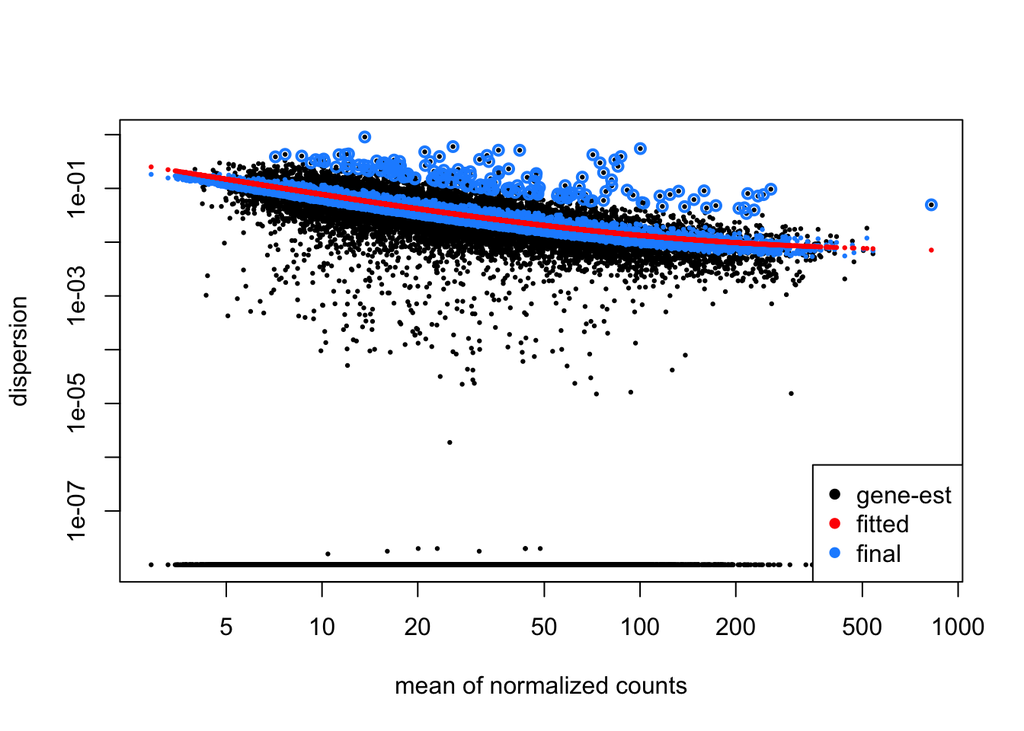

```r
plotDispEsts(tubdds)
```

A more in-depth discussion of this plot is provided in the Harvard Bioinformatics tutorial referenced above. For these data, this dispersion plot looks pretty good.

From this dataset, we can now extract the results of statistical tests from which we can determine whether there are any significantly different regions. Below, I calculate the results in two ways, the first (`res.tub`) is how I usually do things. The second (`res.LFC`) uses a ‘shrinking’ model that will reduce the apparent log fold change for exceptionally noisy peaks while preserving statistically significant (i.e., not noisy) differences between samples.

```r
res.tub = results(tubdds, contrast = c("genotype", "tubopa", "wt13"), independentFiltering = FALSE)
res.LFC = lfcShrink(dds = tubdds, res = res.tub, type = 'apeglm', coef = 3)
```

```
## using 'apeglm' for LFC shrinkage. If used in published research, please cite:
##     Zhu, A., Ibrahim, J.G., Love, M.I. (2018) Heavy-tailed prior distributions for
##     sequence count data: removing the noise and preserving large differences.
##     Bioinformatics. https://doi.org/10.1093/bioinformatics/bty895
```

```r
# convert to data.frame
res.tub = as.data.frame(res.tub)
res.LFC = as.data.frame(res.LFC)

res.tub %>%
  arrange(padj) %>%
  head()
```

```
##                          baseMean log2FoldChange     lfcSE     stat
## chr3L:13119983-13120765 160.32517       2.111722 0.1089609 19.38055
## chr3R:31852132-31852765 121.71825       2.562312 0.1340109 19.12018
## chr3R:20608220-20608587  75.48730       3.441323 0.1903236 18.08143
## chr2L:3549677-3550198    92.93318       2.934136 0.1671888 17.54983
## chr3L:6820918-6821537   152.95544       2.042775 0.1183798 17.25610
## chr3R:29547831-29548479 108.17007       2.130204 0.1306830 16.30054
##                               pvalue         padj
## chr3L:13119983-13120765 1.126333e-83 3.602802e-79
## chr3R:31852132-31852765 1.715103e-81 2.743049e-77
## chr3R:20608220-20608587 4.463844e-73 4.759500e-69
## chr2L:3549677-3550198   5.965489e-69 4.770452e-65
## chr3L:6820918-6821537   1.006782e-66 6.440788e-63
## chr3R:29547831-29548479 9.782265e-60 5.215089e-56
```

Here, I’ve arranged the output of the results by adjusted p-value and am showing the top 6. The rowname refers to the original peak (this is why we named those rows beforehand!).

## Visualization

### PCA

Before we go very far with this comparison, we want to know how similar the replicates are to one another.

We can use built-in functions to perform PCA on the DESeq count data. We *hope* that the first principal component distinguishes the `genotype` of each sample…

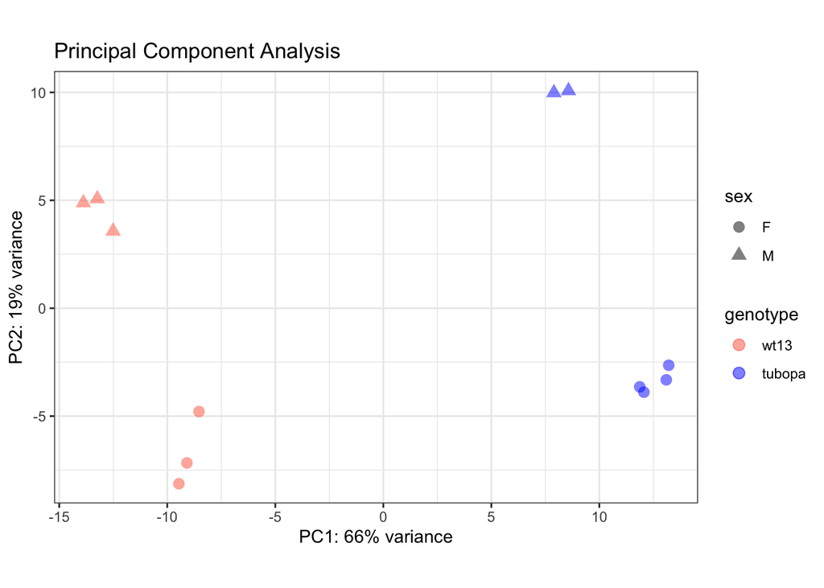

```r
# principal component analysis:
rld = rlog(tubdds, blind = FALSE)
pca = plotPCA(rld, intgroup = c("genotype", "sex"), returnData = TRUE, ntop = 1000)
percentVar = round(100 * attr(pca, "percentVar"))


PC12plot = ggplot(pca, aes(PC1, PC2, color = genotype, shape = sex)) +
  geom_point(size = 3, alpha = 0.5) +
  xlab(paste0("PC1: ", percentVar[1], "% variance")) + ylab(paste0("PC2: ", percentVar[2], "% variance")) +
  scale_color_manual(values = c("tomato", "blue")) + theme(axis.line = element_line(color = "black")) +
  theme_bw() +
  coord_fixed() +
  labs(title = 'Principal Component Analysis')

PC12plot
```

First we process the counts table using the `rlog` function which log-transforms the data and applies the library size data calculated by DESeq2 to minimize library-size differences. Then we use the `plotPCA` function to calculate principal components.

We have done PCA using the top 1000 most variable peaks in this dataset. Similar results are obtained using the entire results list. The first principal component distinguishes the samples on the basis of genotype. The second principal component is substantial. I have assigned ‘shapes’ in the plot on the basis of the sex of the embryo that makes up each sample. The second principal component distinguishes samples on the basis of sex. This tells us that sex has a major impact on the variance in the data. We know this is potantially uninteresting, however, given that much of these differences are likely just due to the fact that male embryos have half as many counts on the X chromosome compared with females. This is why, however, we include `sex` in the formula above as a potential confounding effect on the output of the model.

This gives us confidence that 85% of the variance in the data (or top 1000 most varying regions) are accounted for in the model. If we wanted to delve deeper, we would make plots of PC3, PC4… until we account for nearly all of the variance in the data. But this is generally ‘good enough’ at this point.

For more information on PCA, please see the help for the function `princomp`.

### How can you account for ‘batch effects’?

Batch effects are a significant concern for genomics data sets. By ‘batch effect’, I mean, a technical artifact that stems from the fact that libraries are made on different days, sometimes by different people, and can therefore be different on a day-to-day (or person-by-person) basis. These differences will affect the results in a DESeq2 analysis. The last thing you want to do is to invest very much time thinking about a result that is not rooted in biological differences!

**Ways to minimize batch effects at the bench.**

Be at one with the fact that batch effects are true and significant. It doesn’t matter how good you are at benchwork: you will have batch effects in your libraries. If libraries must be generated over multiple days, try to ensure that each day contains a diverse representation of the different samples/conditions in your experiments. **Don’t process all the controls on one day, and all the ‘treatment’ samples on a different day.** If you do, then you have a big problem, in that you have *confounded* two variables: treatment and prep-date. **Minimize choices that have the potential to confound forseeable differences between samples.**

Similarly, if you are pooling your libraries for sequencing in more than one pool (i.e., you need >1 sequencing run to process your samples), shuffle the prep dates across pools. Don’t confound prep date and library pool variables.

**Ways to account for batch effects in your analysis**

Be aware of what kinds of batch effects could affect your data. Did you switch antibodies or library prep-kits halfway through the experiment? Make a note of which samples go with the old and with the new reagent. Keep track of the dates that libraries are prepped. Keep track of the PCR cycles that you used to amplify. Keep track of *everything*.

When you perform your PCA on your replicates, facet the data by these variables you’ve tracked. For the example above, I guarantee you that somewhere in your PCA, switching from an old to a new aliquot of an antibody will show up as a principal component. If the effect is sufficiently large, you can pass this information to the DESeq2 formula (like we did for `sex`), and it can account for the effect of this in the results.

### MA-Plots

The first thing to do when exploring a dataset like this is to make an MA plot. An MA plot shows the log2-fold change as a function of mean signal.

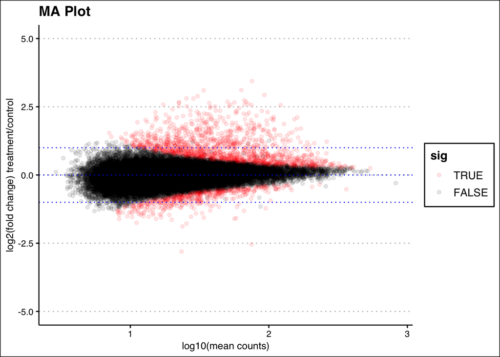

```r
res.tub %>%
  mutate(sig = padj < 0.05) %>%
  ggplot(aes(x = log10(baseMean), y = log2FoldChange, color = sig)) +
  geom_point(alpha = 0.1) +
  coord_cartesian(ylim = c(-5,5)) +
  scale_color_manual(values = c("TRUE" = "red", "FALSE" =  "black")) +
  geom_hline(yintercept = c(0,1,-1), linetype = 'dotted', color = 'blue') +
  theme_clean() +
  labs(title = "MA Plot",
       x = "log10(mean counts)",
       y = "log2(fold change) treatment/control")
```

We can compare with the ‘shrunken’ data:

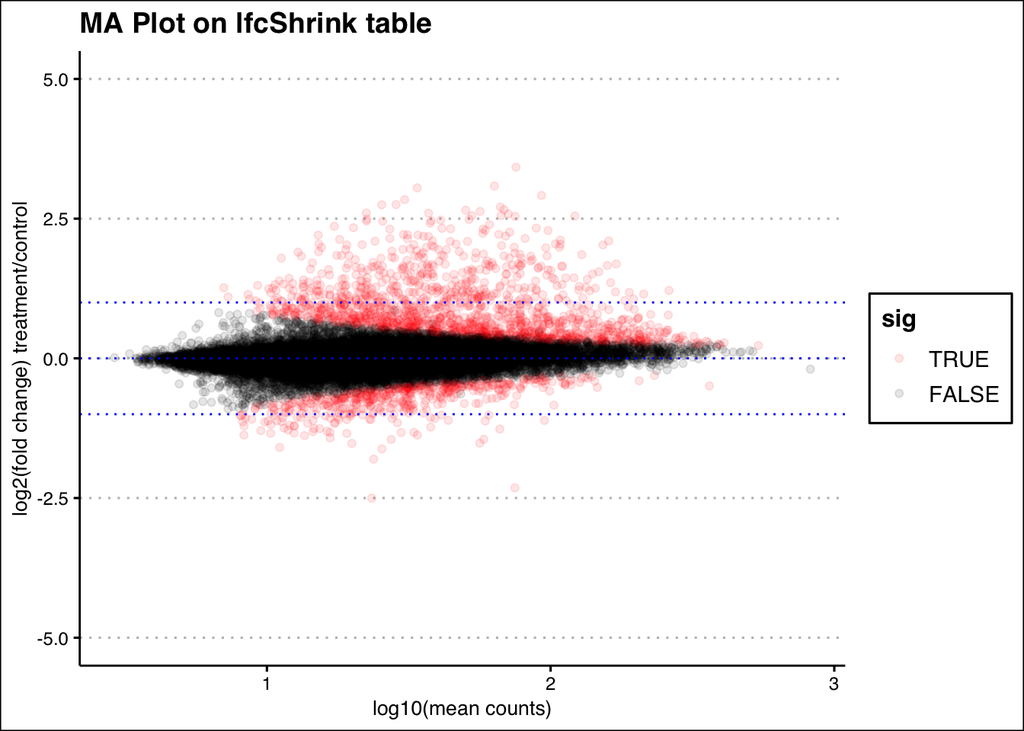

```r
res.LFC %>%
  mutate(sig = padj < 0.05) %>%
  ggplot(aes(x = log10(baseMean), y = log2FoldChange, color = sig)) +
  geom_point(alpha = 0.1) +
  coord_cartesian(ylim = c(-5,5)) +
  scale_color_manual(values = c("TRUE" = "red", "FALSE" =  "black")) +
  geom_hline(yintercept = c(0,1,-1), linetype = 'dotted', color = 'blue') +
  theme_clean() +
  labs(title = "MA Plot on lfcShrink table",
       x = "log10(mean counts)",
       y = "log2(fold change) treatment/control")
```

We can see from this that there are some number of statistically significant peaks that have a positive log2 fold-change (treatment has more signal than control). There are also some that have a negative log2 fold-change. The value of the MA plot is that it tells you where in your average signal distribution the significantly different regions occur. This looks good, but you would want to be cautious, for instance, if all your significant regions were in the very low end of average signal.

Another thing you want to look at is how centered the ‘carrot-shaped’ blob of datapoints is. If it is significantly displaced from y = 0, this suggests that there is some dominant trend in your data that is forcing the mean of the distribution to be not zero, and is symptomatic of failed modeling of the dispersion in the data.

### Volcano Plots

Another way that people like to look at this data is as a volcano plot. The difference between a volcano plot is that it shows the log2 fold change on the x-axis, and the -log10(adjusted p-value) on the y-axis. Note that any information about whether a significant change is happening at a region with high or low overall signal is lost in the basic version:

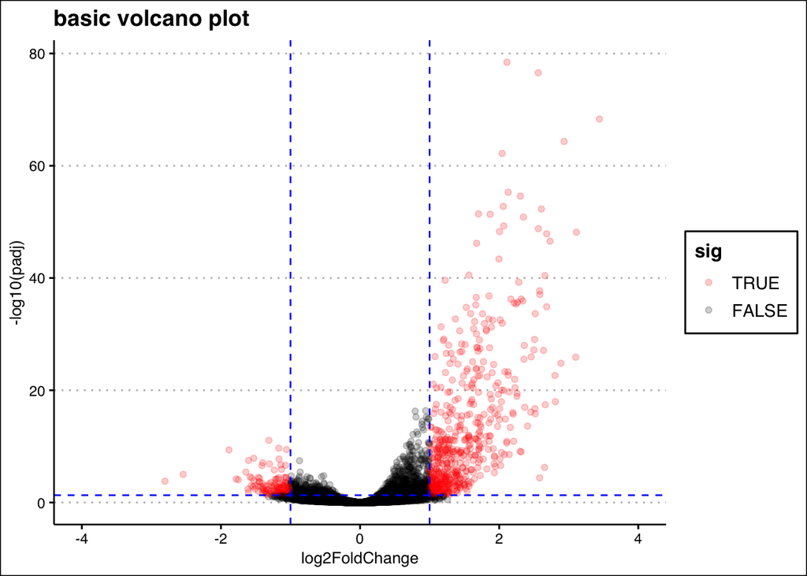

```r
res.tub %>%
  mutate(sig = padj <= 0.05 & abs(log2FoldChange) >= 1) %>%
  ggplot(aes(x = log2FoldChange, y = -log10(padj), color = sig)) +
  geom_point(alpha = 0.2) +
  coord_cartesian(xlim =c(-4,4)) +
  geom_hline(yintercept = -log10(0.05), linetype = 'dashed', col = 'blue') +
  geom_vline(xintercept = log2(c(0.5,2)), linetype = 'dashed', col = 'blue') +
  scale_color_manual(values = c("TRUE" = 'red', "FALSE" = "black")) +
  theme_clean() +
  labs(title = 'basic volcano plot')
```

Here we’ve highlighted not only the regions with a significant adjusted p-value, but also those that have an absolute fold change greater than or equal to 1.

We can use ggplot2 to also include information about the mean signal at each of these points by scaling the size of the points according to this value.

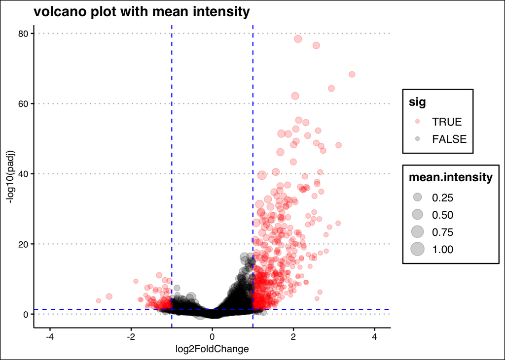

```r
supervolcano = res.tub %>%
  mutate(sig = padj <= 0.05 & abs(log2FoldChange) >= 1) %>%
  mutate(mean.intensity = baseMean/max(baseMean)) %>%
  ggplot(aes(x = log2FoldChange, y = -log10(padj), color = sig, size = mean.intensity)) +
  geom_point(alpha = 0.2) +
  coord_cartesian(xlim =c(-4,4)) +
  geom_hline(yintercept = -log10(0.05), linetype = 'dashed', col = 'blue') +
  geom_vline(xintercept = log2(c(0.5,2)), linetype = 'dashed', col = 'blue') +
  scale_color_manual(values = c("TRUE" = 'red', "FALSE" = "black")) +
  theme_clean() +
  labs(title = 'volcano plot with mean intensity')

supervolcano
```

I have some issues with the way that ggplot automatically generates a legend for these data… it automatically plots the natural quartiles of the data range (0-1), but not the quartiles of the data itself (where 1 = a few points with high signal and the average signal in the data is closer to the 0.25 quartile). Perhaps we can discuss in class how to adjust this.

It is a good idea to state on a plot like this how many points are ‘red’

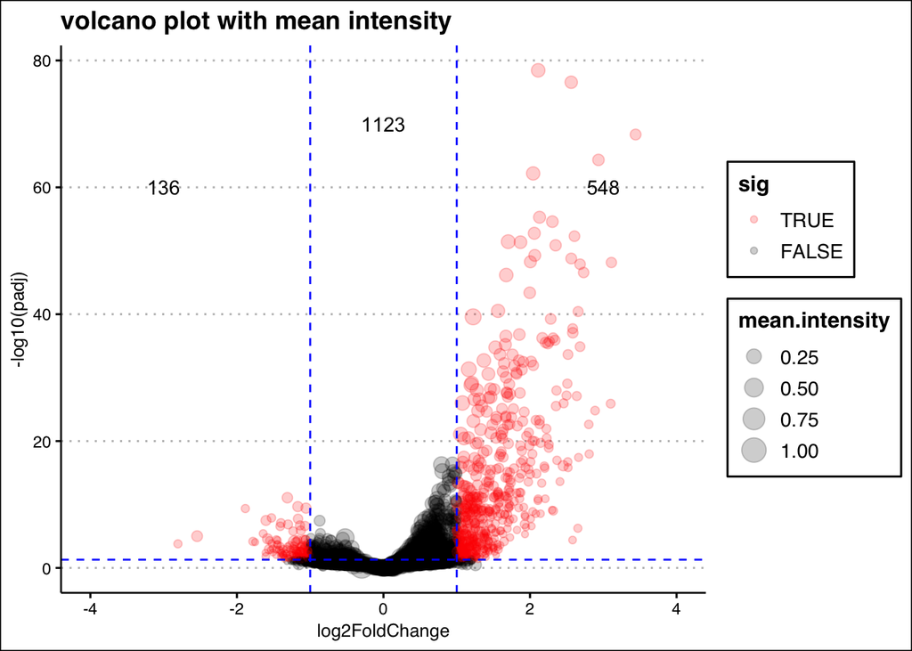

```r
supervolcano +
  annotate(geom = "text", x = -3, y = 60, label = length(which(res.tub$padj <= 0.05 & res.tub$log2FoldChange <= -1))) +
  annotate(geom = "text", x = 3, y = 60, label = length(which(res.tub$padj <= 0.05 & res.tub$log2FoldChange >= 1))) +
  annotate(geom = 'text', x = 0, y = 70, label = length(which(res.tub$padj <= 0.05 & abs(res.tub$log2FoldChange) < 1)))
```

How does the supervolcano look like with the shrunken FC data?

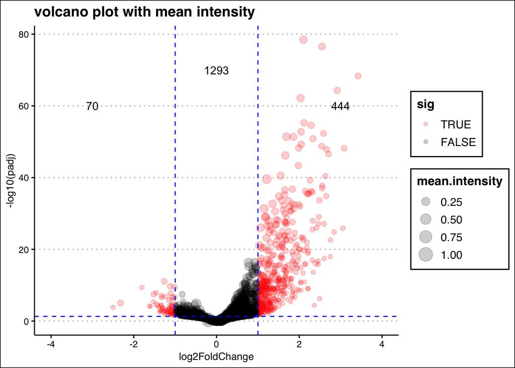

```r
supervolcano2 = res.LFC %>%
  mutate(sig = padj <= 0.05 & abs(log2FoldChange) >= 1) %>%
  mutate(mean.intensity = baseMean/max(baseMean)) %>%
  ggplot(aes(x = log2FoldChange, y = -log10(padj), color = sig, size = mean.intensity)) +
  geom_point(alpha = 0.2) +
  coord_cartesian(xlim =c(-4,4)) +
  geom_hline(yintercept = -log10(0.05), linetype = 'dashed', col = 'blue') +
  geom_vline(xintercept = log2(c(0.5,2)), linetype = 'dashed', col = 'blue') +
  scale_color_manual(values = c("TRUE" = 'red', "FALSE" = "black")) +
  theme_clean() +
  labs(title = 'volcano plot with mean intensity')

supervolcano2 +
  annotate(geom = "text", x = -3, y = 60, label = length(which(res.LFC$padj <= 0.05 & res.LFC$log2FoldChange <= -1))) +
  annotate(geom = "text", x = 3, y = 60, label = length(which(res.LFC$padj <= 0.05 & res.LFC$log2FoldChange >= 1))) +
  annotate(geom = 'text', x = 0, y = 70, label = length(which(res.LFC$padj <= 0.05 & abs(res.LFC$log2FoldChange) < 1)))
```

## “Gene Set” Enrichment with Fisher’s Exact Test

What we have done above is perform DESeq on an ATAC-seq dataset comparing control and misexpression of a pioneer factor. We have found some regions where misexpression of the pioneer results in increased chromatin accessibility. We also have a set of ChIP-seq peaks for where the pioneer factor normally likes to bind. A question that we could have about this data is whether the sites in the ATAC data that show increased accessibility *are also* directly bound by the pioneer.

A more formal way to ask the question is: does selecting the subset of peaks that are directly bound by the pioneer also choose sites that show a significant increase in accessibility greater (or less than) what you would expect from random chance?

We can tabulate these different categories. The total set of regions (e.g., “The Universe”) is the complete set of ATAC-seq peaks upon which we’ve performed differential enrichment analysis. We have from DESeq2 results of a statistical test, and with this we can score whether any ATAC peak has a statistically significant increase above a certain fold change threshold. We can also use Genomic Ranges to easily score whether an ATAC peak overlaps with a ChIP-seq peak for the pioneer. This defines two *categories* of peaks within the Universe of all peaks. However, having two independent categories implies *a total of four categories* : whether a peak is only a member of category 1 or 2, whether a peak is a member of both categories, and whether a peak is a member of neither category.

Let’s first use `GenomicRanges` to tabulate membership in the primary categories.

```r
# whether an ATAC peak is a member of the significantly increased signal above 2-fold increase.

isUp = res.tub$log2FoldChange >= 1 & res.tub$padj <= 0.05

# whether an ATAC peak is a member of the ChIP-seq peaks for our pioneer

isChIP = as.logical(countOverlaps(peaks, opa.ChIP.peaks))

# we can append these to the peaks list as metadata columns

mcols(peaks) = data.frame(isUp, isChIP)

peaks
```

```
## GRanges object with 31987 ranges and 2 metadata columns:
##                          seqnames            ranges strand |      isUp
##                             <Rle>         <IRanges>  <Rle> | <logical>
##          chr2L:5505-6046    chr2L         5505-6046      * |     FALSE
##          chr2L:6585-6881    chr2L         6585-6881      * |     FALSE
##          chr2L:7521-7933    chr2L         7521-7933      * |     FALSE
##          chr2L:8741-8994    chr2L         8741-8994      * |     FALSE
##        chr2L:12481-12571    chr2L       12481-12571      * |     FALSE
##                      ...      ...               ...    ... .       ...
##   chrX:23339582-23339691     chrX 23339582-23339691      * |     FALSE
##   chrX:23344029-23344102     chrX 23344029-23344102      * |     FALSE
##   chrX:23460838-23460946     chrX 23460838-23460946      * |     FALSE
##   chrX:23469707-23469808     chrX 23469707-23469808      * |     FALSE
##   chrX:23472561-23472676     chrX 23472561-23472676      * |     FALSE
##                             isChIP
##                          <logical>
##          chr2L:5505-6046     FALSE
##          chr2L:6585-6881     FALSE
##          chr2L:7521-7933     FALSE
##          chr2L:8741-8994     FALSE
##        chr2L:12481-12571     FALSE
##                      ...       ...
##   chrX:23339582-23339691     FALSE
##   chrX:23344029-23344102     FALSE
##   chrX:23460838-23460946     FALSE
##   chrX:23469707-23469808     FALSE
##   chrX:23472561-23472676     FALSE
##   -------
##   seqinfo: 6 sequences from dm6 genome
```

This is all we need to do a fisher’s exact test. To do a Fisher’s exact test on two categories, we need to build a 2 x 2 “contingency table” where the two rows are “Condition 1 = TRUE” and “Condition 1 = FALSE”, and the two colums are “Condition 2 = TRUE” and “Condition 2 = FALSE”. If you sketch this out, you should see how the four cells in the table will give us the *four implied* categories I discussed above.

What follows is an ugly but verbose way to compose this table from the two logical vectors we generated above.

```r
contingency = rbind(
  c(sum(peaks$isUp & peaks$isChIP), sum(peaks$isUp & !peaks$isChIP)),
  c(sum(!peaks$isUp & peaks$isChIP), sum(!peaks$isUp & !peaks$isChIP))
)

colnames(contingency) = c("isChIP", "!isChIP")
rownames(contingency) = c("isUp", "!isUp")

contingency
```

```
##       isChIP !isChIP
## isUp     270     278
## !isUp    598   30841
```

We don’t really need to do statistics here to see that we’re on to something. The IsChIP column shows that 1/3 of peaks are also in the up category. The Not IsChIP column shows that ~1/110 peaks are in the up category. This is objectively an enrichment, it is unquestionably of large magnitude, and doing the statistical test is a formality.

We can check that we have made this properly by calculating row and column sums, and looking for values that we expect.

First, the **entire table should sum to the number of elements in the Universe (i.e., ATAC peaks).**

```r
sum(contingency) == length(peaks)
```

```
## [1] TRUE
```

Second, we know we have a certain number of peaks in the ChIP peak list. If all of them are members of the ATAC peak list, then the sum of the “isChIP” column should equal the number of ATAC peaks that overlap ChIP peaks.

```r
colSums(contingency)[1] == sum(as.logical(countOverlaps(peaks, opa.ChIP.peaks)))
```

```
## isChIP
##   TRUE
```

Finally, the sum of the “isUp” column should equal the number of ATAC peaks that scored above our significance/fold change threshold with the DESeq data.

```r
rowSums(contingency)[1] == sum(res.tub$log2FoldChange >= 1 & res.tub$padj <= 0.05)
```

```
## isUp
## TRUE
```

**I recommend doing these tests for yourself because it is easy to mix up the composition of the contingency table, and the results of the fisher’s test will not make sense if you swap one of the numbers or mis-count membership in the groups.**

Once we have our contingency table, we can now perform Fisher’s exact test:

```r
test.result = fisher.test(contingency)

test.result
```

```
##
##  Fisher's Exact Test for Count Data
##
## data:  contingency
## p-value < 2.2e-16
## alternative hypothesis: true odds ratio is not equal to 1
## 95 percent confidence interval:
##  41.37407 60.49132
## sample estimates:
## odds ratio
##   50.05719
```

We have performed a two-tailed fisher’s exact test asking whether membership in the ChIP peaks list is over (or under) enriched for regions with membership in the significantly ‘up’ regions from the DESeq data.

The two-tailed p-value is displayed above as less than 10^-16, but the exact test should tell us the exact p-value we can get that by asking for it.

```r
test.result$p.value
```

```
## [1] 2.054572e-282
```

Very ‘significant’. But we did a two-tailed test. How do we know that this represents enrichment versus depletion? The reported value of the “odds ratio” is the key here. In plain language, the odds ratio would be equal to one if category 1 and category 2 were completely independent of one another. Values greater than one indicate the strength of the association between category 1 and category 2. Values less than one (and greater than zero) indicate the anti-association between category 1 and category 2.

**For the fisher’s exact test (and any statistical test you ever ever ever do), the p-value is itself meaningless if the magnitude of the effect is not considered. The odds ratio is your summary of the magnitude of the association that you are testing for. It is up to you to judge whether, despite the significant p-value, you are convinced that the enrichment (or depletion) is sufficiently large.**

Because of the nature of the odds-ratio, where depletion occupies values from zero to one, and enrichment occupies values from 1 to infinity, it therefore makes sense to report it as the log2(odds ratio).

```r
log2(test.result$estimate)
```

```
## odds ratio
##   5.645505
```

For these types of data, an odds ratio of this magnitude is quite impressive, and so in conjunction with the p-value, we can safely conclude that significant increases detected by DESeq are significantly enriched for sites that are directly bound by the pioneer.